# Problem Set 6

Clinton Tepper

## Problem 1

In terms of sigma, as $\Phi(0)=0.5$ and $\frac{1}{\sigma}\phi(0)=\frac{1}{\sqrt{2\pi\sigma^{2}}}$. Starting from the likelihood function:

$$\begin{align*}
\prod_{i=1}^{n}\left(Q_{i}\right)= & \prod_{i=1}^{n}\left(\begin{cases}
\frac{1}{\sqrt{2\pi\sigma^{2}}}exp\left(\frac{-\left(y_{i}-\beta x_{i}\right)^{2}}{2\sigma^{2}}\right) & y_{i}>0\\
1-\Phi\left(\frac{x_{i}}{\sigma}\right) & y_{i}\le0
\end{cases}\right)
\end{align*}$$

And working with the log likelihood function:

$$\begin{align*}
\sum_{i=1}^{n}\left(l_{i}\right)=\begin{cases}
\frac{-\left(y_{i}-\beta x_{i}\right)^{2}}{2\sigma^{2}}-\frac{1}{2}ln\left(2\pi\sigma^{2}\right) & y_{i}>0\\
log\left(\Phi\left(\frac{-x_{i}}{\sigma}\right)\right) & y_{i}\le0
\end{cases}
\end{align*}$$

We calculate the gradiant as follows:

$$\begin{align*}
\\
\frac{\partial l}{\partial\sigma}= & \sum_{i=1}^{n}\begin{cases}
\frac{\left(y_{i}-\beta x_{i}\right)^{2}}{\sigma^{3}}-\frac{1}{\sigma} & y_{i}>0\\
\frac{x_{i}\phi\left(\frac{-x_{i}}{\sigma}\right)}{\sigma^{2}\Phi\left(\frac{-x_{i}}{\sigma}\right)} & y_{i}\le0
\end{cases}\\
\frac{\partial l}{\partial\beta}= & \sum_{i=1}^{n}\begin{cases}
\frac{x_{i}\left(y_{i}-\beta x_{i}\right)^{2}}{\sigma^{2}} & y_{i}>0\\
0 & y_{i}\le0
\end{cases}
\end{align*}$$

The following code creates the sampling distribution for the MLE:

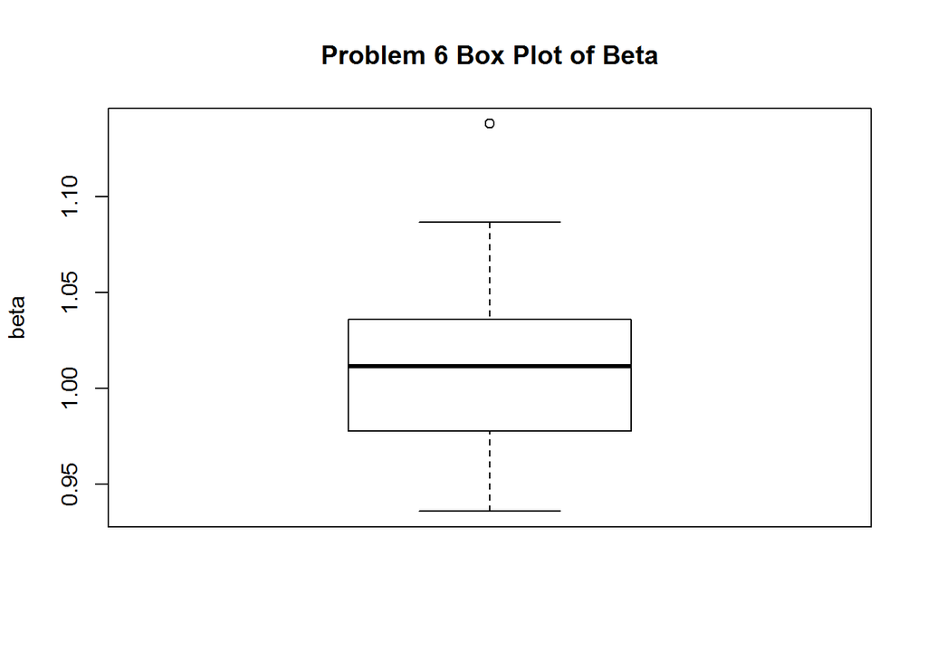

```r
#The likelihood function for a two column data set where data is censored below C
#In: C, sigma, beta, xVec, yVec
#Out: likelihood
tobitLogLike = function(beta, sigma, cutoff, xVec, yVec) {
    minLike = -10 ^ 8;
    #minimum likelihood to prevent -inf results
    singleLike = function(x, y)
        log(if (y > cutoff) dnorm(y - beta * x, 0, sigma) else pnorm(cutoff - beta * x, 0, sigma));
    return(max(sum(mapply(singleLike, xVec, yVec)), minLike));
}

#The gradiant of the tobit likelihood function for a two column data set where data is censored below C
#In: C, sigma, beta, xVec, yVec
#Out: gradient of the tobit likelihood
tobitGradLogLike = function(beta, sigma, cutoff, xVec, yVec) {
    minLike = -10 ^ 8;
    #minimum likelihood to prevent -inf results
    singleGrad = function(x, y) matrix(
            if (y > cutoff) c(x * (y - beta * x) / sigma ^ 2, (y - beta * x) ^ 2 / sigma ^ 3 - 1 / sigma)
    else c(0, - x / sigma ^ 2 * dnorm( - x / sigma) / pnorm( - x / sigma)), ncol = 2);
            #calculates one value for the likelihood

    return(apply(mapply(singleGrad, xVec, yVec), 1, function(x) max(sum(x), minLike)));
}


#Simulates y|x provided that y|x is normally distributed about beta*x
#In: alpha, beta, sigma, a vector of x values, (optional) a cutoff for censored values
#Out: a vector of simulated y values
simLinYData = function(alpha, beta, sigma, xVec, cutOff) {
    if (missing(cutOff))
        return(mapply(function(x, e) alpha + beta * x + sigma * e, xVec, rnorm(length(xVec))));
    return(mapply(function(x, e) max(alpha + beta * x + sigma * e, cutOff), xVec, rnorm(length(xVec))));
}

##########################Problem 1 Entry Point##########################
#define the simulation parameters
numVals = 1000;
numSampleSets = 50;

#boundaries for optimization
sigmaMin = 0.1;
sigmaMax = 2;
betaMin = -3;
betaMax = 3;

# the true population paramaters
betaPop = 1;
sigmaPop = 0.6;
alphaPop = 0;

#create a matrix of x values
xVector = runif(numVals, -1, 1);

#simulate the y values for each sample set
yVectors = apply(matrix(rep(xVector, numSampleSets), nrow = numVals, ncol = numSampleSets),
2, function(x) simLinYData(alphaPop, betaPop, sigmaPop, x, 0));

#simulate the maximum likelihood for each data set

optimFunc = function(y) optim(c(.5, .5), function(betaSigma) - tobitLogLike(betaSigma[1], betaSigma[2], 0, xVector, y),
    function(betaSigma) - tobitGradLogLike(betaSigma[1], betaSigma[2], 0, xVector, y),
    method = "L-BFGS-B", lower = c(betaMin, sigmaMin), upper = c(betaMax, sigmaMax));

mleResults = apply(yVectors, 2, optimFunc);

mleParResults = matrix(NA, numSampleSets, 2)
for (j in 1:numSampleSets) {
    mleParResults[j,] = mleResults[[j]]$par;
}

#boxplots
boxplot(mleParResults[, 1], main = "Problem 6 Box Plot of Beta", ylab = "beta");
```

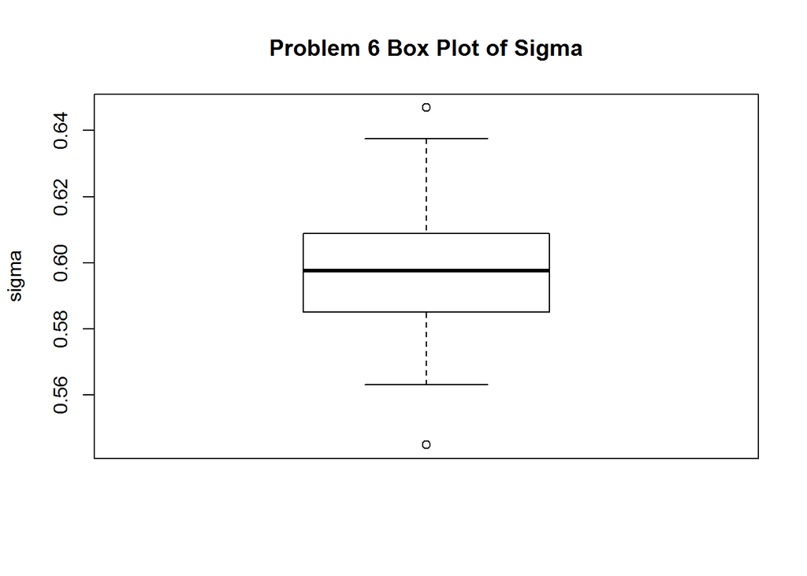

```r
boxplot(mleParResults[, 2], main = "Problem 6 Box Plot of Sigma", ylab = "sigma");
```

We conclude by noting that the empirical evidence suggests that the median of the sampling distribution converges to the true parameters of $\beta=1$ and $\sigma=0.6$.

## Problem 2

### Part i

In this problem, we make the assumption that the value of a given alternative is determined by two componenets. The first component, $\alpha_{j}$, represents the value of the alternative to the subject net of price. The second component, $\beta_{p}$, represents the value of the log of money. Because the utility of money remains constant, $\beta_{p}$ stays constant across alternatives. Thus we view the NET value of a purchasing decision as $\alpha_{j}$, and the gross value of an alternative to the subject as $\alpha_{j}+\beta_{p}P_{j}$.

### Part ii

The likelihood function for ${ _{j}} $ can be denoted as:

$$\begin{align*}
L\left(\alpha,\beta_{p}\right)= & \prod_{i=1}^{N}\left(Pr\left(X_{i}=j\right)\right)\\
L\left(\alpha,\beta_{p}\right)= & \prod_{i=1}^{N}\left(\frac{exp\left(\alpha_{j}+\beta_{p}ln\left(P_{j}\right)\right)}{\sum_{k=1}^{J}exp\left(\alpha_{k}+\beta_{p}ln(P_{k})\right)}\right)
\end{align*}$$

Taking the log:

$$\begin{align*}
l\left(\alpha,\beta_{p}\right)= & \sum_{i=1}^{N}\left(\alpha_{j}+\beta_{p}ln(P_{j})-log\left(\sum_{k=1}^{J}exp\left(\alpha_{k}+\beta_{p}ln\left(P_{k}\right)\right)\right)\right)\\
l\left(\alpha,\beta_{p}\right)= & \sum_{i=1}^{N}\left(\alpha_{j}+\beta_{p}ln(P_{j})\right)-Nlog\left(\sum_{k=1}^{J}exp\left(\alpha_{k}+\beta_{p}ln\left(P_{k}\right)\right)\right)
\end{align*}$$

Let $\eta_{j}$ be the number of times alternative j was chosen. Then:

$$\begin{align*}
\frac{\partial l\left(\alpha,\beta_{p}\right)}{\partial\alpha_{j}}= & \eta_{j}-\frac{Nexp\left(\alpha_{j}+\beta_{p}ln\left(P_{j}\right)\right)}{\sum_{k=1}^{J}exp\left(\alpha_{k}+\beta_{p}ln\left(P_{j}\right)\right)}\\
\frac{\partial l\left(\alpha,\beta_{p}\right)}{\partial\alpha_{j}}= & \sum_{k=1}^{J}\eta_{k}ln(P_{k})-\frac{\sum_{k=1}^{J}ln\left(P_{k}\right)Nexp\left(\alpha_{k}+\beta_{p}ln\left(P_{k}\right)\right)}{\sum_{k=1}^{J}exp\left(\alpha_{k}+\beta_{p}ln\left(P_{k}\right)\right)}
\end{align*}$$

But $\frac{\partial l\left(\alpha,\beta_{p}\right)}{\partial\beta_{p}}=\sum_{k=1}^{N}\frac{\partial l\left(\alpha,\beta_{p}\right)}{\partial\alpha_{k}}ln\left(P_{k}\right)$. Therefore, the first order constraints are not linearly independent, and we are left with J equations and J+1 unknown parameters. Specifically, if we set $\alpha_{1}=0$, we have a maximum of J equations and J unknowns. One easy way to fix this issue is to look at the relative prefrences rather than the absolute prefrences. In other words, we can fix $\alpha_{1}+\beta P_{1}=0$, and look at the relative differences in the preferences for the other parameters.

### Part iii/iv

```r
#The likelihood function for a multinomial distribution
#In: A set of parameters and a data set
#Out: The sum of the log likelihoods for each data point
logitLogLike = function(V, cMat) {
    minLike = -10 ^ 8;
    denom = matrix(apply(V, 2, function(x) log(sum(exp(x)))),nrow=1);
    #calculate the denominator for each price
    #calculate the log probability for each value of v
    logPVec = t(apply(V, 1, function(x) x - denom));

    #The below command looks up the logged probability for each entry in cMat and sums the total
    return(max(sum(sapply(1:ncol(V), function(x) sum(logPVec[cMat[, x], x])), minLike)));
}

#A wrapper function for logitLike amenable to the setup in problem 6
# Note that a null alternative is added. The null alternative is assumed to be J=1.
#In: Alpha, Beta, and the  data set
#Out: The sum of the log likelihoods for each data point
multinomChoiceModelLike = function(alpha, beta, lPrice, cMat) {

    #form the matrix of Vs
    return(logitLogLike(apply(lPrice, 2, function(x) alpha + beta * x), cMat));
}

#A gradient function specific to problem 6
# Note that a null alternative is added. The null alternative is assumed to be J=1.
#In: Alpha, Beta, price, and the  data set. Alpha[0] and price[0] are assumed to be zero.
#Out: The gradient of the likelihood
multinomChoiceModelGrad = function(alpha, beta, lPrice, cMat) {
    L = nrow(cMat);
    W = ncol(cMat);
    J = length(alpha);
    eta = matrix(sapply(1:J,
        function(x) apply(cMat, 2, function(y) sum(y == x))), nrow = J, ncol = W, byrow = TRUE);
        #calculate the denominator for each price series
    denom = apply(lPrice, 2, function(x) sum(exp(alpha + x * beta)));
    #the below return calculates and sums the gradients accross prices

    return(rbind(matrix(sapply(2:J,
        function(x) sum(eta[x,] - L * exp(alpha[x] + beta * lPrice[x,]) / denom)),ncol=1),
        sum(sapply(1:J,
            function(x) sum(lPrice[x,] * (eta[x,] - L * exp(alpha[x] + beta * lPrice[x,]) / denom))))));
}

##########################Problem 5 Entry Point##########################

#Define the Parameters
numSamples = 100;
numPriceVectrs = 200;
alpha = matrix(NA, 3);
alpha[1] = 0;
alpha[2] = 0.5;
alpha[3] = 1.5;
beta = 2;
lowerBound = 0.1;
upperBound = 5;

numPrices = length(alpha);
#get the prices
logPrices = rbind(matrix(rep(0, numPriceVectrs), nrow = 1),
    matrix(runif(numPriceVectrs * (numPrices - 1), -1, 1), nrow = numPrices - 1));

#Simulate the data
popPVec = exp(rep(alpha, numPriceVectrs) + logPrices * beta);
popPVec = apply(popPVec, 2, function(x) x/sum(x));
sampMat = matrix(sapply(1:numPriceVectrs,
    function(x) sample.int(numPrices, numSamples, replace = TRUE, popPVec[, x])),
    nrow = numSamples, ncol = numPriceVectrs);

#Get the maximum likelihood of the parameters
likeFunc = function(alphaBeta)
    - multinomChoiceModelLike(rbind(0, matrix(alphaBeta[1:(numPrices - 1)], nrow = numPrices-1)),
        alphaBeta[numPrices], logPrices, sampMat);

gradFunc = function(alphaBeta)
    - multinomChoiceModelGrad(rbind(0, matrix(alphaBeta[1:(numPrices - 1)], nrow = numPrices-1)),
        alphaBeta[numPrices], logPrices, sampMat);

out = optim(c(rep(1, numPrices)), likeFunc, gradFunc,
    method = "L-BFGS-B",
    lower = c(rep(lowerBound, numPrices)),
    upper = c(rep(upperBound, numPrices)));

print(out);
```

```
## $par
## [1] 0.4921492 1.4966474 2.0112580
##
## $value
## [1] 100015226
##
## $counts
## function gradient
##        8        8
##
## $convergence
## [1] 0
##
## $message
## [1] "CONVERGENCE: REL_REDUCTION_OF_F <= FACTR*EPSMCH"
```

In most simulations, the value of $\alpha_2$, $\alpha_3$, and $\beta$, denoted as PAR respectivelly in the output above, are reasonably close to the true values of $\alpha_2=0.5$, $\alpha_3=1.5$, and $\beta=2$.

## Problem 3

The true distribution can be computed as the probability that all samples are less than x. In this case, the cumulative distribution comes to $(\frac{x}{\theta})^{50}$ while the density function can be calculated as $50\left(\frac{x}{\theta}\right)^{49}$. As shown in the histograms below, the parametric distribution is much closer to the true distribution.

The following code creates histograms for the non-parametric and parametric bootstraps, as well as the sampling distribution for reference.

```r
#Creates a non-parametric bootstrap distribution from a population distribution given an
#arbitrary sample statistic (1 arg)
#In: population data, a stat function (1 arg), number of samples per draw, number of draws
#Out: a vector of bootstraps
boot.NPBootStrapper = function(datSet, statFunc, samplesPerDraw, numDraws) {

    return(matrix(sapply(1:numDraws,
    function(x) statFunc(sample(datSet, samplesPerDraw, replace = TRUE))),
    numDraws));
}


#Creates a parametric bootstrap distribution from a population distribution given an
#arbitrary sample statistic (1 arg)
#In: a function with parameters estimated (1arg, a stat function (1 arg),
# number of samples per draw, number of draws
#Out: a vector of bootstraps
boot.PBootStrapper = function(estFunc, statFunc, samplesPerDraw, numDraws) {

    return(matrix(sapply(1:numDraws, function(x) statFunc(estFunc(samplesPerDraw))), numDraws));
}

#Creates a sample distribution from a population function given an
#arbitrary sample statistic (1 arg)
#In: population fucntion (1 arg which takes in number of samples per draw), a stat function (1 arg),
# number of samples per draw, number of draws
#Out: a vector of sample calculations
boot.sampleDist = function(popFunc, statFunc, samplesPerDraw, numDraws) {
    return(matrix(sapply(rep(samplesPerDraw, numDraws), function(x) statFunc(popFunc(x))), numDraws));
}

#######################Problem 3 Script Entry Point###############
draws = 10000;
datSize = 50;
popGen = function(x) runif(x);
#define the statistic and population generator function
statGen = function(x) max(x);

dataSet = popGen(datSize);
#acquire the data set
datStat = statGen(dataSet);
problemDist = boot.NPBootStrapper(dataSet, statGen, datSize, draws);

cat("\n\nThe problem 3 non-parametric standard error is:\n");
```

```
##
##
## The problem 3 non-parametric standard error is:
```

```r
cat(var(problemDist) ^ .5);
```

```
## 0.03804349
```

```r
cat("\n\nThe pivotal non-parametric confidence interval is:\n");
```

```
##
##
## The pivotal non-parametric confidence interval is:
```

```r
CIPivotal = c(2 * datStat - quantile(problemDist, .025), 2 * datStat - quantile(problemDist, .975));
cat(CIPivotal);
```

```
## 1.044201 0.9626225
```

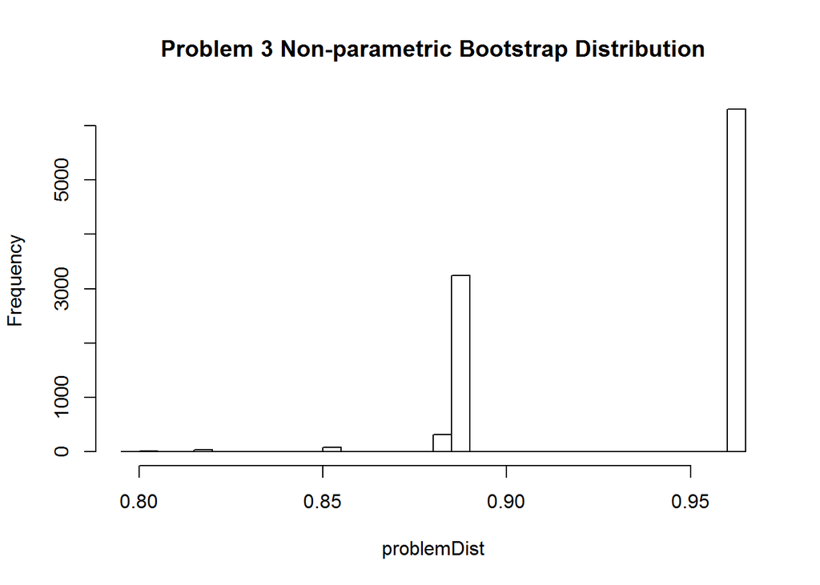

```r
hist(problemDist, 50, main = "Problem 3 Non-parametric Bootstrap Distribution");
```

```r
problemDist = boot.PBootStrapper(function(x) runif(x, 0, datStat), statGen, datSize, draws);

cat("\n\nThe problem 3 parametric standard error is:\n");
```

```
##
##
## The problem 3 parametric standard error is:
```

```r
cat(var(problemDist) ^ .5);
```

```
## 0.0186407
```

```r
cat("\n\nThe pivotal parametric confidence interval is:\n");
```

```
##
##
## The pivotal parametric confidence interval is:
```

```r
CIPivotal = c(2 * datStat - quantile(problemDist, .025), 2 * datStat - quantile(problemDist, .975));
cat(CIPivotal);
```

```
## 1.032467 0.9630952
```

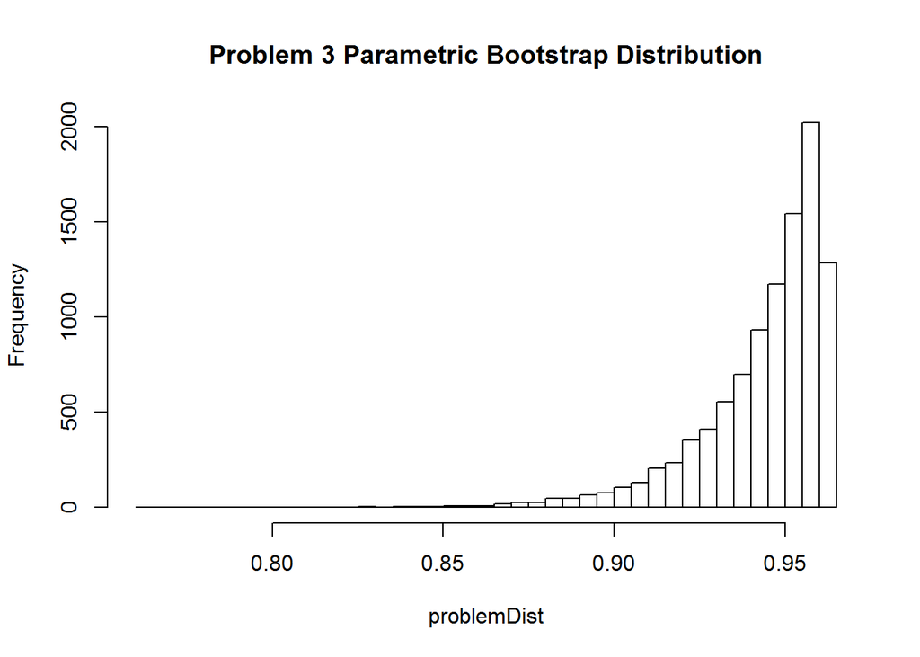

```r
hist(problemDist, 50, main = "Problem 3 Parametric Bootstrap Distribution");
```

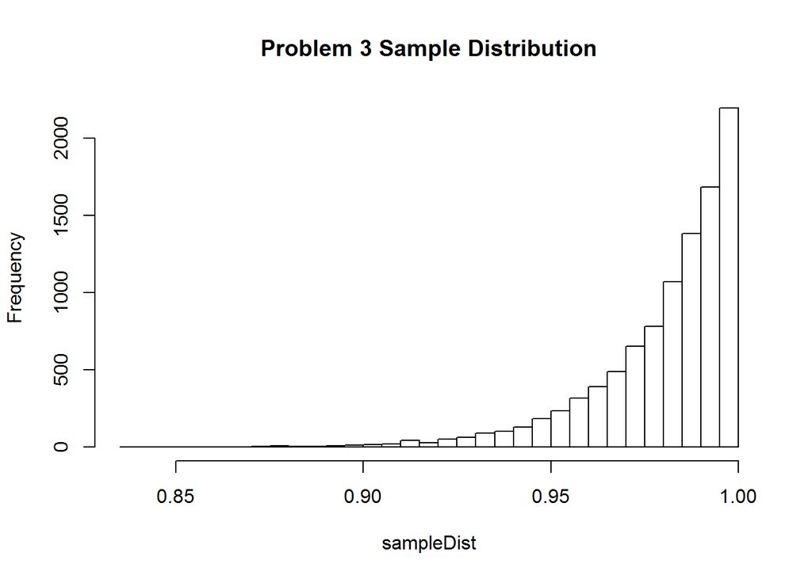

```r
sampleDist = boot.sampleDist(popGen, statGen, datSize, draws)
hist(sampleDist, 50, main = "Problem 3 Sample Distribution");
```

We conclude by noting that the parametric bootstrap has greater efficacy, as demonstrated by the above histograms, than the non-parametric bootstrap for the distribution of interest in this problem.